# Developing Data Products Shiny App Assignment

Yigit Ozan Berk

10/8/2019

# Introduction

- This app uses the Credit data set from ISLR package.
- It analyzes the relationships between Income and other predictors.
- It presents an input button for “student” variable indicator, and two sliders for “balance” and “rating” variable inputs for prediction.
- It plots the residuals of the regression model of formula = Income ~ Rating*Balance + Student

# Exploratory Analysis

The model is selected from the analysis of predictors in the Credit dataset.

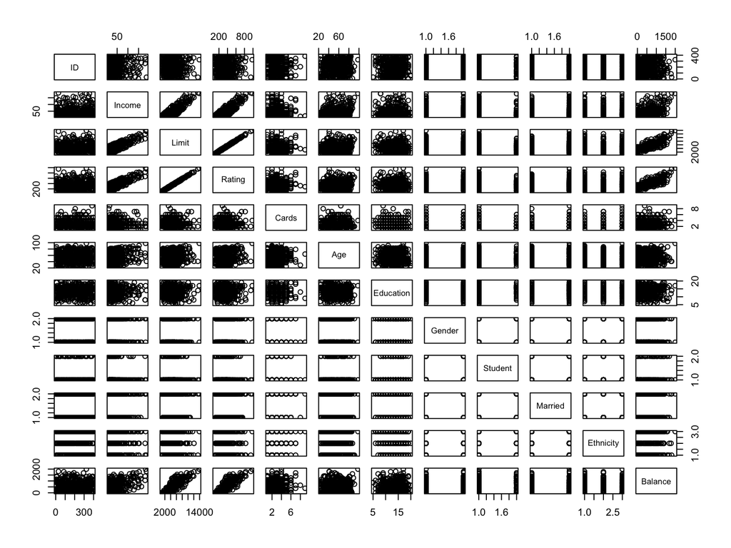

```r
pairs(Credit)
```

# Selecting Predictors

The model begins with the most significant predictors, ‘StudentYes’, ‘Balance’ and ‘Limit’. Upon further examination, because ‘Rating’ and ‘Limit’ is very highly correlated with a value of 0.9968797 , ‘Rating’ predictor is used instead of ‘Limit’ because it makes more sense.

```
##
## Call:
## lm(formula = Income ~ . - ID, data = Credit)
##
## Residuals:
##     Min      1Q  Median      3Q     Max
## -17.743  -7.523  -3.269   5.247  34.496
##
## Coefficients:
##                      Estimate Std. Error t value Pr(>|t|)
## (Intercept)        -51.112552   4.005333 -12.761  < 2e-16 ***
## Limit                0.018885   0.003647   5.179  3.6e-07 ***
## Rating               0.142889   0.054040   2.644  0.00852 **
## Cards                1.307204   0.484530   2.698  0.00728 **
## Age                 -0.005469   0.032611  -0.168  0.86691
## Education           -0.139732   0.176240  -0.793  0.42835
## GenderFemale        -1.403516   1.092952  -1.284  0.19986
## StudentYes          41.212185   2.170377  18.988  < 2e-16 ***
## MarriedYes          -0.489574   1.143892  -0.428  0.66890
## EthnicityAsian       1.722499   1.557909   1.106  0.26956
## EthnicityCaucasian   0.689833   1.347651   0.512  0.60903
## Balance             -0.094956   0.002850 -33.314  < 2e-16 ***
## ---
## Signif. codes:  0 '***' 0.001 '**' 0.01 '*' 0.05 '.' 0.1 ' ' 1
##
## Residual standard error: 10.9 on 388 degrees of freedom
## Multiple R-squared:  0.907,  Adjusted R-squared:  0.9044
## F-statistic: 344.1 on 11 and 388 DF,  p-value: < 2.2e-16
```

# Anova

Upon further examination of the variance, the ‘Cards’ predictor is not used because of unnecessary variance inflation, together with low F statistic.

```
## Analysis of Variance Table
##
## Model 1: Income ~ Rating * Balance + Student
## Model 2: Income ~ Rating * Balance + Student + Cards
##   Res.Df   RSS Df Sum of Sq      F Pr(>F)
## 1    395 34986
## 2    394 34954  1    32.348 0.3646 0.5463
```

# Conclusion

- Using multivariate regression with the following formula

```
##
## Call:
## lm(formula = Income ~ Rating * Balance + Student, data = Credit)
##
## Coefficients:
##    (Intercept)          Rating         Balance      StudentYes
##     -4.310e+01       3.609e-01      -1.173e-01       3.940e+01
## Rating:Balance
##      7.031e-05
```

the user can get a good idea of the value of income of a person(student or non-student) given his rating and balance values.

- The app offers two sliders and an input button to prepare the model prediction value.
- The app calculates and displays the prediction value after the values are submitted to the server by the submit button.